# Lab 4: MATH 4753

Justin Kleiber

2019-09-13

# Task 1

First, the working directory is confirmed

```r
getwd()
```

```
## [1] "C:/Users/jklei/Google Drive/School/Fall 2019/MATH4573/Lab4"
```

# Task 2

Now the spruce tree data will be imported

```r
spruce.df = read.csv("SPRUCE.csv")
tail(spruce.df)
```

```
##    BHDiameter Height
## 31       17.7   19.9
## 32       20.7   19.4
## 33       21.0   20.4
## 34       13.3   15.5
## 35       15.9   17.6
## 36       22.9   19.2
```

# Task 3

First, a lowess smoother scatter plot is made to see the trend in data

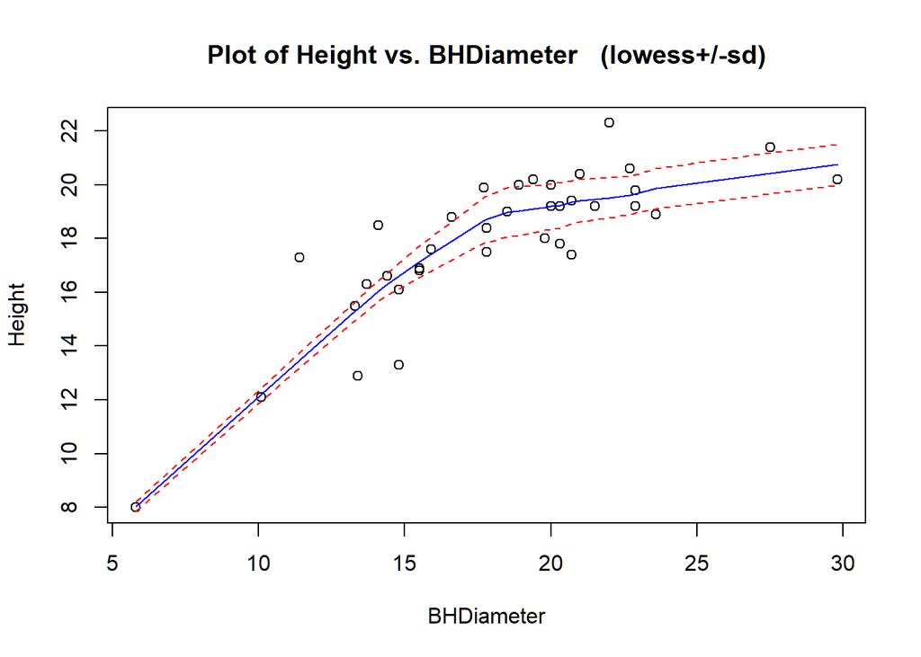

```r
# Load the s20x library and make a lowess smoother scatter plot
library(s20x)
trendscatter(Height~BHDiameter, f = 0.5, data = spruce.df)
```

A linear model is created. Residuals and fitted values are found from this model.

```r
# Make a linear model
spruce.lm = with(spruce.df, lm(Height~BHDiameter))

# Find height residuals
height.res = residuals(spruce.lm)

# Find fitted values for height
height.fit = fitted(spruce.lm)
```

The residuals are plotted against the fitted values.

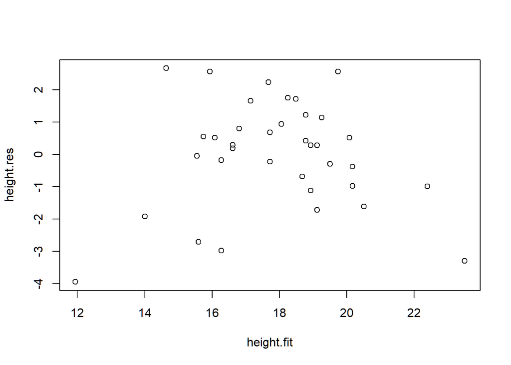

```r
# Plot residuals vs fitted values
plot(height.fit, height.res)
```

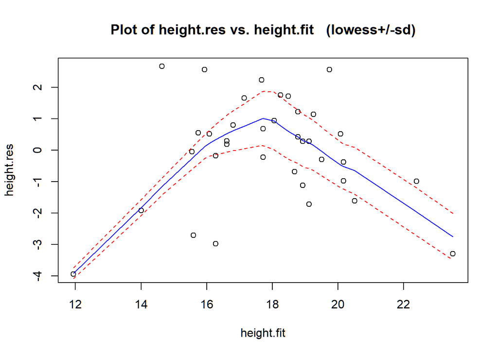

```r
trendscatter(height.fit, height.res)
```

This curve has a steep positive slope that turns into a steep negative slope. In the original curve, there was a steep positive slope followed by a less steep positive slope.

Next, a residual plot is made using the plot() function

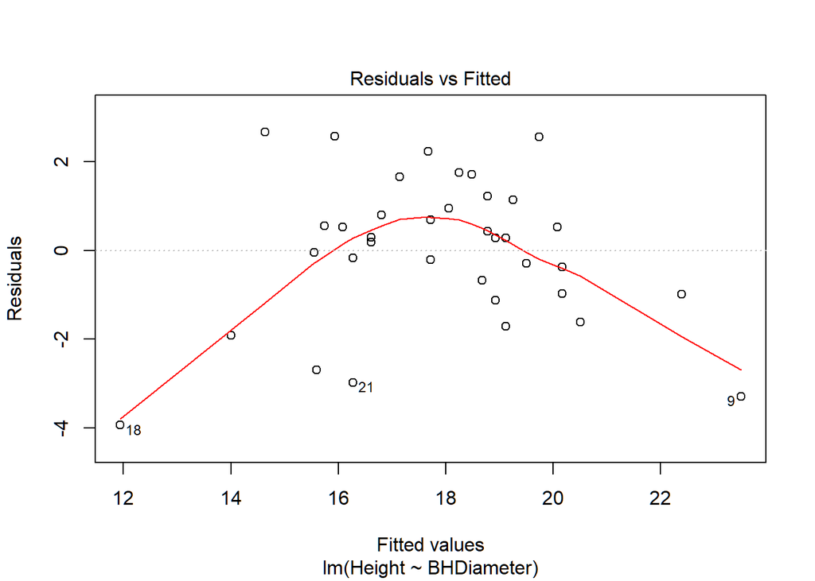

```r
# Make a residual plot
plot(spruce.lm, which =1)
```

The normality of the linear model can be tested using the normcheck function

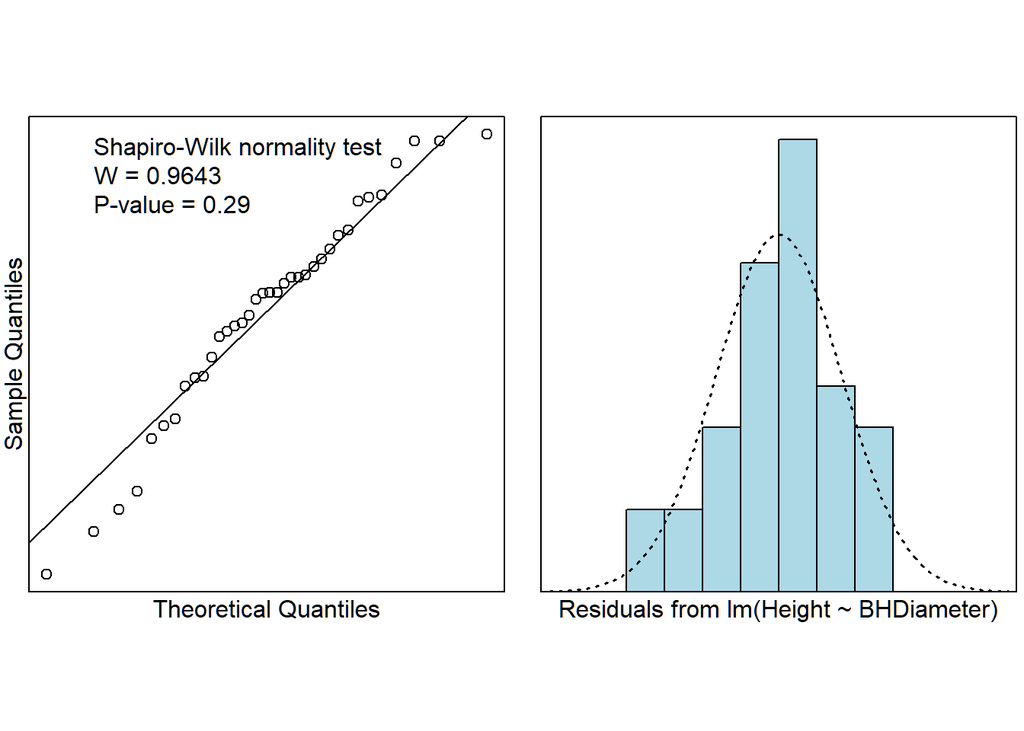

```r
# Test the normality of the linear model
normcheck(spruce.lm, shapiro.wilk = TRUE)
```

The P-value for the Shapiro-Wilk test is 0.29. The null hypothesis is that the data is normally distributed

The mean of the residuals is near 0, as shown below.

```r
mean(height.res)
```

```
## [1] -3.087567e-17
```

# Task 4

First, a quadratic line will be made to try to get a better fit on the data

```r
# Fit a quadratic line to the data
quad.lm=lm(Height~BHDiameter + I(BHDiameter^2), data=spruce.df)
```

Now the quadratic line is plotted on top of the scatter plot

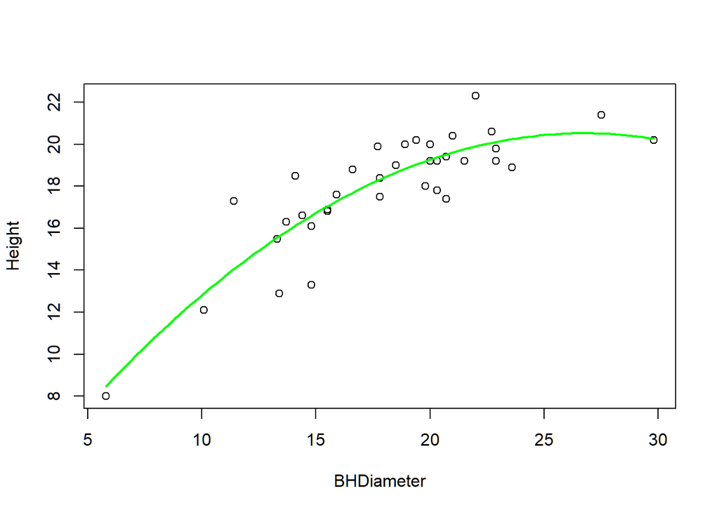

```r
# Plot height vs diameter with the quadratic trendline overlaid
with(spruce.df, plot(BHDiameter, Height))

# Make the quadratic trendline
quad_trend = function(x){
  quad.lm$coef[1] +quad.lm$coef[2]*x  + quad.lm$coef[3]*x^2
}

# Add the trendline
curve(quad_trend, lwd = 2, col = "green", add = TRUE)
```

The fitted values can now be found, and the residuals will be plotted against them

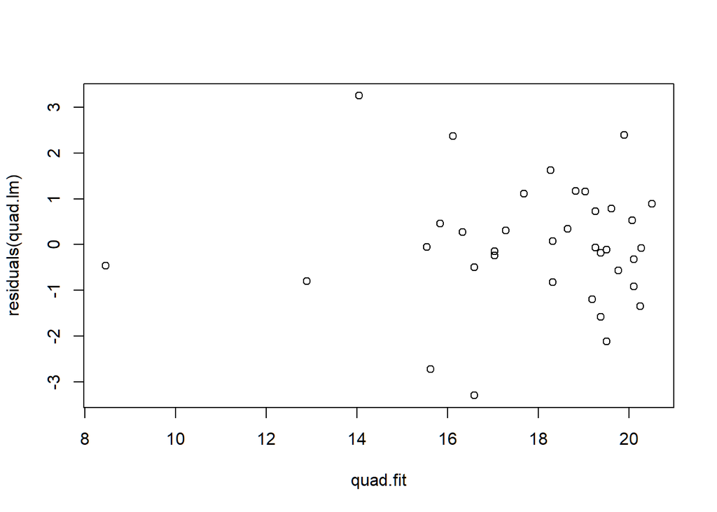

```r
# Fitted values for the quadratic trend
quad.fit = fitted(quad.lm)

# Plot the residuals against the fitted quadratic function
plot(quad.fit, residuals(quad.lm))
```

Now the quadratic line can be tested to see if the residuals are normally distributed

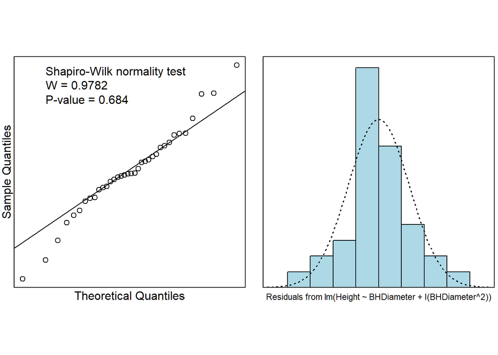

```r
# Test the normality of the quadratic line
normcheck(quad.lm, shapiro.wilk = TRUE)
```

The P-value of this test is 0.684, which is higher than the last test on the straight line model. This indicates the quadratic line fits the data better than the straight line.

# Task 5

The quadratic line is summarized below:

```r
summary(quad.lm)
```

```
##
## Call:
## lm(formula = Height ~ BHDiameter + I(BHDiameter^2), data = spruce.df)
##
## Residuals:
##     Min      1Q  Median      3Q     Max
## -3.2966 -0.6245 -0.0707  0.7442  3.2541
##
## Coefficients:
##                  Estimate Std. Error t value Pr(>|t|)
## (Intercept)      0.860896   2.205022   0.390 0.698731
## BHDiameter       1.469592   0.243786   6.028 8.88e-07 ***
## I(BHDiameter^2) -0.027457   0.006635  -4.138 0.000227 ***
## ---
## Signif. codes:  0 '***' 0.001 '**' 0.01 '*' 0.05 '.' 0.1 ' ' 1
##
## Residual standard error: 1.382 on 33 degrees of freedom
## Multiple R-squared:  0.7741, Adjusted R-squared:  0.7604
## F-statistic: 56.55 on 2 and 33 DF,  p-value: 2.182e-11
```

This shows that $\hat{\beta}_0 = 0.860896$, $\hat{\beta}_1 = 1.469592$, and $\hat{\beta}_2 = -0.027457$.

The confidence intervals for the model are as follows:

```r
# Get the confidence intervals of the model coefficients
ciReg(quad.lm)
```

```
##                 95 % C.I.lower    95 % C.I.upper
## (Intercept)           -3.62525           5.34705
## BHDiameter             0.97361           1.96558
## I(BHDiameter^2)       -0.04096          -0.01396
```

Using the estimates for beta, we can make the following equation
$$y = \hat{\beta}_0 + \hat{\beta}_{1}x + \hat{\beta}_{2}x^2$$
which simplifies to:
$$y = 0.860896 + 1.469592x -0.027457x^2$$

This function is used by the predict function in R to predict height values from diameter values. This is shown below:

```r
# Predict height from diameter
predict(quad.lm, data.frame(BHDiameter=c(15,18,20)))
```

```
##        1        2        3
## 16.72690 18.41740 19.26984
```

The straight line model has the following predictions:

```r
# Predict height from diameter
predict(spruce.lm, data.frame(BHDiameter=c(15,18,20)))
```

```
##        1        2        3
## 16.36895 17.81338 18.77632
```

For these diameters, the quadratic line predicts higher values than the straight model.

To see how well each model fits the data, the summary should be considered. Below are the summaries for each model

```r
# Straight line model
summary.lm(spruce.lm)
```

```
##
## Call:
## lm(formula = Height ~ BHDiameter)
##
## Residuals:
##     Min      1Q  Median      3Q     Max
## -3.9394 -0.9763  0.2829  0.9950  2.6644
##
## Coefficients:
##             Estimate Std. Error t value Pr(>|t|)
## (Intercept)  9.14684    1.12131   8.157 1.63e-09 ***
## BHDiameter   0.48147    0.05967   8.069 2.09e-09 ***
## ---
## Signif. codes:  0 '***' 0.001 '**' 0.01 '*' 0.05 '.' 0.1 ' ' 1
##
## Residual standard error: 1.678 on 34 degrees of freedom
## Multiple R-squared:  0.6569, Adjusted R-squared:  0.6468
## F-statistic:  65.1 on 1 and 34 DF,  p-value: 2.089e-09
```

```r
# quadratic line
summary.lm(quad.lm)
```

```
##
## Call:
## lm(formula = Height ~ BHDiameter + I(BHDiameter^2), data = spruce.df)
##
## Residuals:
##     Min      1Q  Median      3Q     Max
## -3.2966 -0.6245 -0.0707  0.7442  3.2541
##
## Coefficients:
##                  Estimate Std. Error t value Pr(>|t|)
## (Intercept)      0.860896   2.205022   0.390 0.698731
## BHDiameter       1.469592   0.243786   6.028 8.88e-07 ***
## I(BHDiameter^2) -0.027457   0.006635  -4.138 0.000227 ***
## ---
## Signif. codes:  0 '***' 0.001 '**' 0.01 '*' 0.05 '.' 0.1 ' ' 1
##
## Residual standard error: 1.382 on 33 degrees of freedom
## Multiple R-squared:  0.7741, Adjusted R-squared:  0.7604
## F-statistic: 56.55 on 2 and 33 DF,  p-value: 2.182e-11
```

As seen above, the multiple R-squared for quad.lm is 0.7741, which is higher than the 0.6569 of the straight line’s multiple R-squared.

R allows for an easy way to find the adjusted R-squared:

```r
# Adjusted R-squared for the straight line
summary.lm(spruce.lm)$adj.r.squared
```

```
## [1] 0.6468239
```

```r
# Adjusted R-squared for the quadratic curve
summary.lm(quad.lm)$adj.r.squared
```

```
## [1] 0.7604373
```

The quadratic line has a higher adjusted R-squared, implying it has a better fit to the data than the straight line estimate.

In this case, multiple R-squared means how closely the model fits to the data. In other words, it is how close the residuals are to the trend line.

The quadratic line thus explains the most variability in the height, as it fits the data the best. The straight line is not able to do adapt as well to the variability.

anova() output for the two models is below:

```r
# Analysis of the straight line
anova(spruce.lm)
```

```
## Analysis of Variance Table
##
## Response: Height
##            Df  Sum Sq Mean Sq F value    Pr(>F)
## BHDiameter  1 183.245 183.245  65.101 2.089e-09 ***
## Residuals  34  95.703   2.815
## ---
## Signif. codes:  0 '***' 0.001 '**' 0.01 '*' 0.05 '.' 0.1 ' ' 1
```

```r
# Analysis of the quadratic line
anova(quad.lm)
```

```
## Analysis of Variance Table
##
## Response: Height
##                 Df  Sum Sq Mean Sq F value    Pr(>F)
## BHDiameter       1 183.245 183.245  95.975 2.701e-11 ***
## I(BHDiameter^2)  1  32.696  32.696  17.125 0.0002269 ***
## Residuals       33  63.007   1.909
## ---
## Signif. codes:  0 '***' 0.001 '**' 0.01 '*' 0.05 '.' 0.1 ' ' 1
```

Next, TSS, MSS and RSS will be found:

```r
# Find the total sum of squares
TSS = with(spruce.df, sum((Height-mean(Height))^2))
TSS
```

```
## [1] 278.9475
```

```r
# Find the model sum of squares
MSS = with(spruce.df, sum((quad.fit-mean(Height))^2))
MSS
```

```
## [1] 215.9407
```

```r
# Find the residual sum of squares
RSS=with(spruce.df, sum((Height-quad.fit)^2))
RSS
```

```
## [1] 63.00683
```

And so, MSS/TSS is:

```r
MSS / TSS
```

```
## [1] 0.7741266
```

which is the R-squared value for the quadratic line!

# Task 6

Unusual points are found below using a cooks plot:

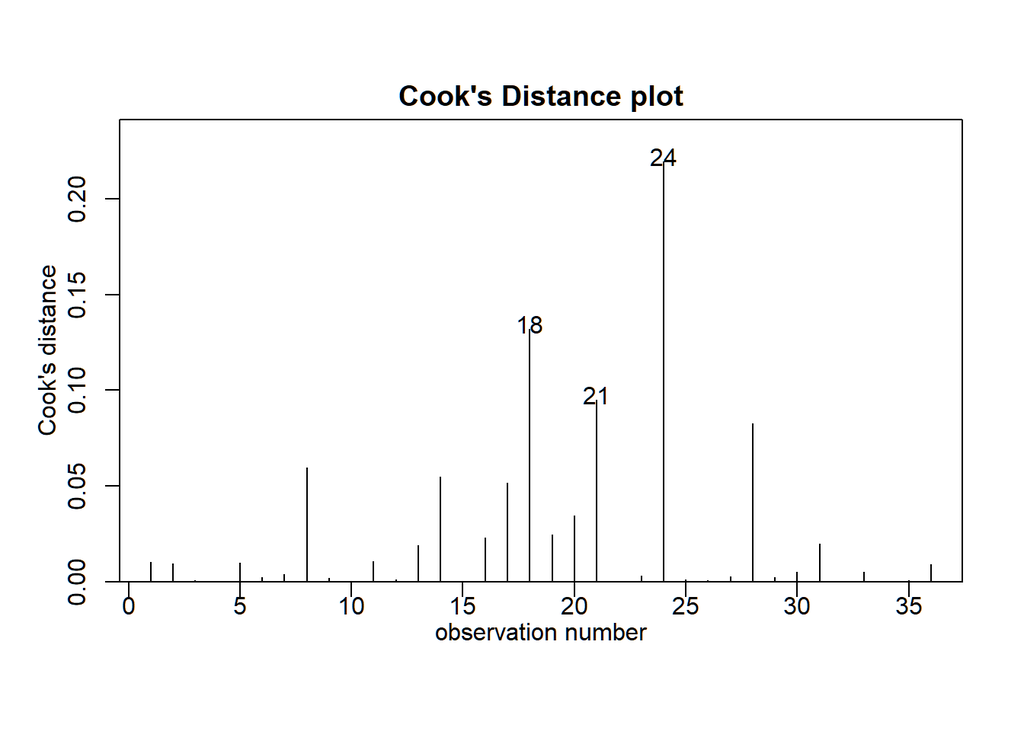

```r
cooks20x(quad.lm)
```

Cooks distance is a measure of how much a model changes if a specific data point is removed from the sample. The plot itself shows the impact each observation has on the model, which can help identify influential data points.

From this it is seen that the quadratic line is most influenced by data point 24. If data point 24 is removed, and a new model is created, it can be seen how the model changes.

```r
# Make a new quadratic line without data point 24
quad2.lm = lm(Height~BHDiameter + I(BHDiameter^2), data = spruce.df[-24,])

# Summary of the new model
summary(quad2.lm)
```

```
##
## Call:
## lm(formula = Height ~ BHDiameter + I(BHDiameter^2), data = spruce.df[-24,
##     ])
##
## Residuals:
##      Min       1Q   Median       3Q      Max
## -3.11233 -0.48227  0.01253  0.71727  2.59146
##
## Coefficients:
##                  Estimate Std. Error t value Pr(>|t|)
## (Intercept)     -0.341500   2.068479  -0.165     0.87
## BHDiameter       1.564793   0.226102   6.921 7.78e-08 ***
## I(BHDiameter^2) -0.029242   0.006114  -4.782 3.74e-05 ***
## ---
## Signif. codes:  0 '***' 0.001 '**' 0.01 '*' 0.05 '.' 0.1 ' ' 1
##
## Residual standard error: 1.266 on 32 degrees of freedom
## Multiple R-squared:  0.8159, Adjusted R-squared:  0.8044
## F-statistic: 70.91 on 2 and 32 DF,  p-value: 1.74e-12
```

The summary of the old quadratic line is below for reference:

```r
summary(quad.lm)
```

```
##
## Call:
## lm(formula = Height ~ BHDiameter + I(BHDiameter^2), data = spruce.df)
##
## Residuals:
##     Min      1Q  Median      3Q     Max
## -3.2966 -0.6245 -0.0707  0.7442  3.2541
##
## Coefficients:
##                  Estimate Std. Error t value Pr(>|t|)
## (Intercept)      0.860896   2.205022   0.390 0.698731
## BHDiameter       1.469592   0.243786   6.028 8.88e-07 ***
## I(BHDiameter^2) -0.027457   0.006635  -4.138 0.000227 ***
## ---
## Signif. codes:  0 '***' 0.001 '**' 0.01 '*' 0.05 '.' 0.1 ' ' 1
##
## Residual standard error: 1.382 on 33 degrees of freedom
## Multiple R-squared:  0.7741, Adjusted R-squared:  0.7604
## F-statistic: 56.55 on 2 and 33 DF,  p-value: 2.182e-11
```

As seen, the new quadratic line is a better fit to the new data than the old model. It can be concluded that data point 24 was too influential on the data set as a whole, which caused disturbance of the model. This could mean data point 24 is an outlier.

# Task 7

Proof:
$$line \space 1: y = \beta_0 + \beta_1x\\
line \space 2: y = \beta_0 + \delta + (\beta_1 + \beta_2)x \\
y_k = \beta_0 + \beta_1x_k = \beta_0 + \delta + (\beta_1 + \beta_2)x_k \\
\beta_0 + \beta_1x_k = \beta_0 + \delta + (\beta_1 + \beta_2)x_k \\
0 = \delta + \beta_2x_k\\
\delta = -\beta_2x_k$$
So:
$$line \space 2: y = \beta_0 + \delta + (\beta_1 + \beta_2)x \\
\delta = -\beta_2x_k \\
y = \beta_0 - \beta_2x_k + \beta_1x + \beta_2x \\
y = \beta_0 + \beta_1x + \beta_2(x - x_k) \space for \space x > x_k$$
To account for the line before $x_k$:
$$line 1: y = \beta_0 + \beta_1x\\
and \\
y = \beta_0 + \beta_1x + \beta_2(x - x_k) \space for \space x > x_k \\
so\\
y = \beta_0 + \beta_1x \space for \space x \leq x_k$$
Therefore, the equation $y = \beta_0 + \beta_1x + \beta_2(x - x_k)I(x > x_k)$ holds.

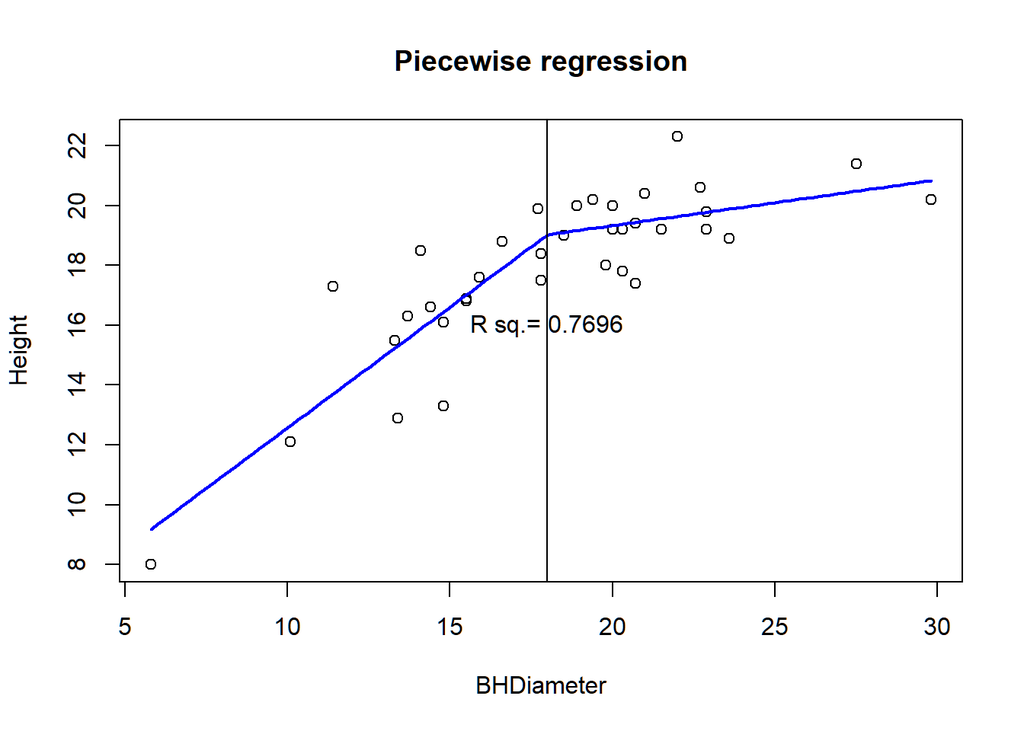

```r
## piecewise linear model in R
## Model y = b0 + b1x + b2(x-xk)*(x>xk)
## You will need to change the code appropriately
sp2.df=within(spruce.df, X<-(BHDiameter-18)*(BHDiameter>18))

lmp=lm(Height~BHDiameter + X,data=sp2.df)
tmp=summary(lmp)

myPlot = function(x,coef){
  coef[1]+coef[2]*(x) + coef[3]*(x-18)*(x-18>0)
}

# Plot the piecewise regression
plot(spruce.df,main="Piecewise regression")
curve(myPlot(x,coef=tmp$coefficients[,"Estimate"] ),add=TRUE, lwd=2,col="Blue")
abline(v=18)
text(18,16,paste("R sq.=",round(tmp$r.squared,4) ))
```

# Task 8

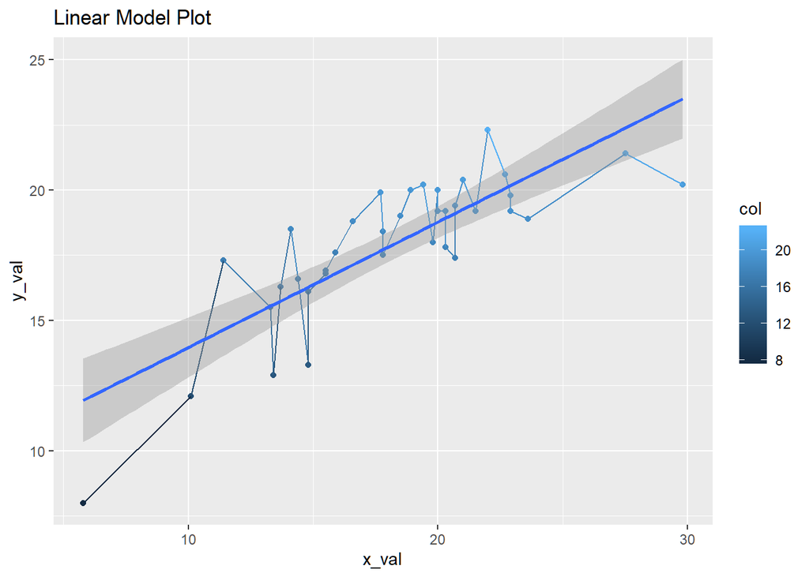

```r
library(JKleiberPkg)
with(spruce.df, plotLM(spruce.df, BHDiameter, Height, Height, "Linear Model Plot"))
```

This function plots all of the data points on a graph and colors it. It also shows a trendline for a straight line model of the data with shading.